# Jeremy Mulcahey: Assignment 3

[figure not shown]

```python
import numpy as np
import pandas as pd
import math
import matplotlib
import matplotlib.pyplot as plt
import statsmodels.tsa as tsa
from statsmodels.tsa.arima_model import ARIMA as arima
import datetime
import time
%matplotlib inline
```

[figure not shown]

```python
#read the csv file
PendData = np.loadtxt('data/pendData.csv', skiprows=1, delimiter=',')

#convert the numpy structure into a pandas DataFrame
PendFrame = pd.DataFrame(PendData,columns=['time(sec)','position(theta)','AR2','ARstep','ARstep2','ARstep3','ARstep4'])
AR2 = PendFrame['AR2']
Time = PendFrame['time(sec)']
Theta = PendFrame['position(theta)']
ARstep = PendFrame['ARstep']
ARstep2 = PendFrame['ARstep2']
ARstep3 = PendFrame['ARstep3']
ARstep4 = PendFrame['ARstep4']
```

```python
PendTS = pd.Series(index = Time)
PendTS[0:] = Theta
```

```python
AR2TS = pd.Series(index = Time)
AR2TS[0:] = AR2
```

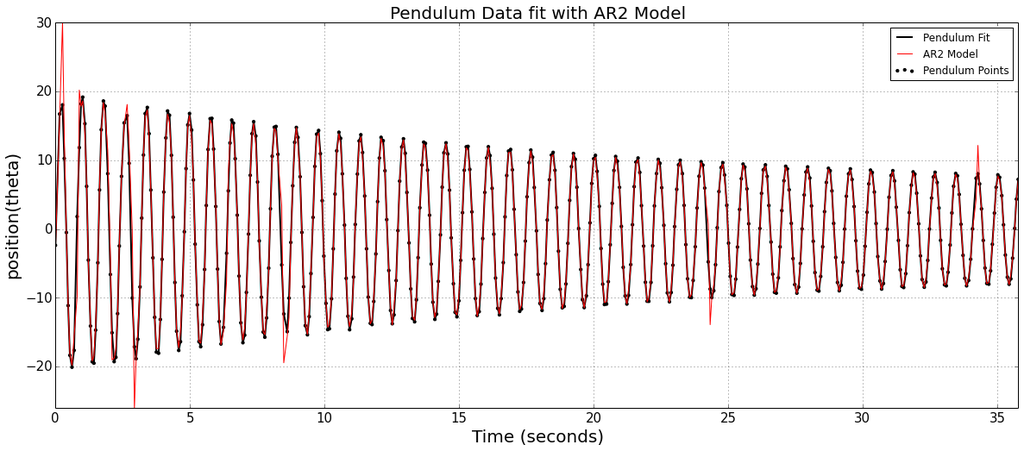

```python
#open a figure window and color it white
figure = plt.figure(figsize=(20,8))

TSPlot = PendTS.plot(linewidth=2, c='black', ylim=(-26,30))

Line2 = AR2TS.plot(linewidth=1, c='red')

#set x and y labels, title, and adjust thier sizes according
TSPlot.set_ylabel('position(theta)', fontsize=20)
TSPlot.set_xlabel('Time (seconds)',fontsize=20)
TSPlot.set_title('Pendulum Data fit with AR2 Model',fontsize=20)
plt.tick_params(axis='both', labelsize=15)
plt.scatter(PendFrame['time(sec)'],PendFrame['position(theta)'], s=10, c='black')


TSPlot.legend(('Pendulum Fit', 'AR2 Model','Pendulum Points'), loc=1);
```

[figure not shown]

```python
nume = sum((PendTS - AR2TS)**2)
denom = sum((PendTS-np.mean(PendTS))**2)
1 - (float(nume)/denom)
```

```
0.97972087733766122
```

Approximately 98% of the variation in the pendulum time series data (theta) can be explained by an optimized AR2 model of theta.

[figure not shown]

```python
ARstepTS = pd.Series(index = Time)
ARstepTS[0:] = ARstep
```

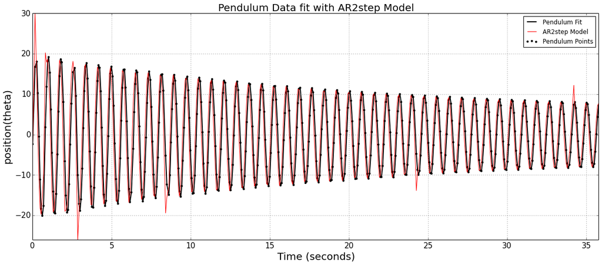

```python
#open a figure window and color it white
figure = plt.figure(figsize=(20,8))

TSPlot = PendTS.plot(linewidth=2, c='black', ylim=(-26,30))

Line2 = ARstepTS.plot(linewidth=1, c='red')

#set x and y labels, title, and adjust thier sizes according
TSPlot.set_ylabel('position(theta)', fontsize=20)
TSPlot.set_xlabel('Time (seconds)',fontsize=20)
TSPlot.set_title('Pendulum Data fit with AR2step Model',fontsize=20)
plt.tick_params(axis='both', labelsize=15)
plt.scatter(PendFrame['time(sec)'],PendFrame['position(theta)'], s=10, c='black')


TSPlot.legend(('Pendulum Fit', 'AR2step Model','Pendulum Points'), loc=1);
```

[figure not shown]

```python
nume = sum((PendTS - ARstepTS)**2)
denom = sum((PendTS-np.mean(PendTS))**2)
1 - (float(nume)/denom)
```

```
0.69435303750161381
```

Comparing the R-square values (.98 vs. .69) we can see that the 1-step ahead did not match the pendulum data as well as the AR(2) model. We can also see this in the time series plot from part c). The first peak in the 1-step model is quite large and the rest of the plot seems to be shifted (slightly) away from the sine wave, where as the AR(2) model appeared to overlay on the sine wave almost point for point (with the exception of the 3 or 4 overestimated peaks).

```python
#if the coefficients are both large
ARstepTS2 = pd.Series(index = Time)
ARstepTS2[0:] = ARstep2

#if the coefficients are both small
ARstepTS3 = pd.Series(index = Time)
ARstepTS3[0:] = ARstep3

#if the coefficients have their signs switched
ARstepTS4 = pd.Series(index = Time)
ARstepTS4[0:] = ARstep4
```

Let's look at the large case first. If both coefficients are increased to 5 and -5 (from 1.7 and -1).

[figure not shown]

```python
#open a figure window and color it white
figure = plt.figure(figsize=(20,8))

TSPlot = PendTS.plot(linewidth=2, c='black', ylim=(-26,30))

Line2 = ARstepTS2.plot(linewidth=1, c='red')

#set x and y labels, title, and adjust thier sizes according
TSPlot.set_ylabel('position(theta)', fontsize=20)
TSPlot.set_xlabel('Time (seconds)',fontsize=20)
TSPlot.set_title('Pendulum Data fit with AR2 Model (Large Coefficients)',fontsize=20)
plt.tick_params(axis='both', labelsize=15)
plt.scatter(PendFrame['time(sec)'],PendFrame['position(theta)'], s=10, c='black')


TSPlot.legend(('Pendulum Fit', 'AR2 Model','Pendulum Points'), loc=1);
```

Increasing the coefficients greatly scales the fit of the AR(2) model.

What happens when the cofficients are reduced? Now .3 and -.3, respectively.

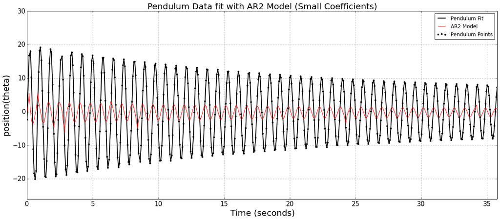

```python
#open a figure window and color it white
figure = plt.figure(figsize=(20,8))

TSPlot = PendTS.plot(linewidth=2, c='black', ylim=(-26,30))

Line2 = ARstepTS3.plot(linewidth=1, c='red')

#set x and y labels, title, and adjust thier sizes according
TSPlot.set_ylabel('position(theta)', fontsize=20)
TSPlot.set_xlabel('Time (seconds)',fontsize=20)
TSPlot.set_title('Pendulum Data fit with AR2 Model (Small Coefficients)',fontsize=20)
plt.tick_params(axis='both', labelsize=15)
plt.scatter(PendFrame['time(sec)'],PendFrame['position(theta)'], s=10, c='black')


TSPlot.legend(('Pendulum Fit', 'AR2 Model','Pendulum Points'), loc=1);
```

Smaller scalers shrinks the fit and appears to have shifted the peaks.

Next we'll switch the signs of phi_1 and phi_2.

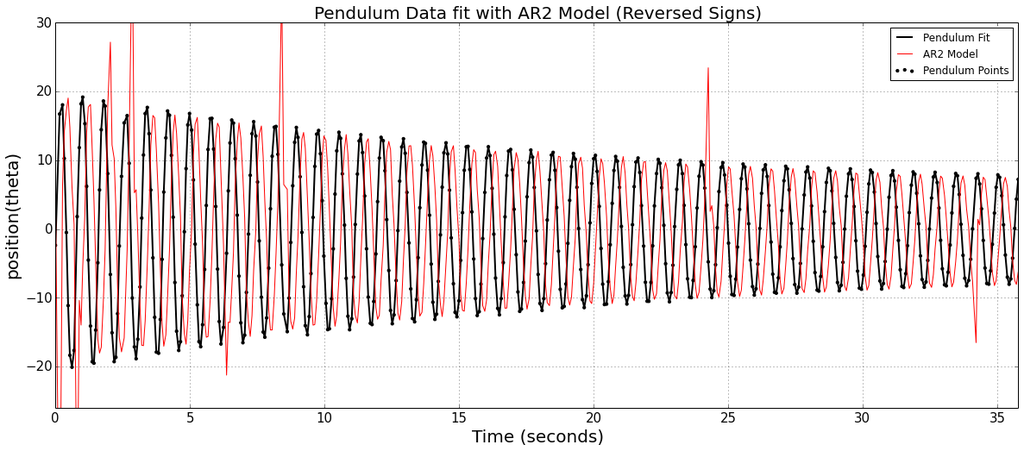

```python
#open a figure window and color it white
figure = plt.figure(figsize=(20,8))

TSPlot = PendTS.plot(linewidth=2, c='black', ylim=(-26,30))

Line2 = ARstepTS4.plot(linewidth=1, c='red')

#set x and y labels, title, and adjust thier sizes according
TSPlot.set_ylabel('position(theta)', fontsize=20)
TSPlot.set_xlabel('Time (seconds)',fontsize=20)
TSPlot.set_title('Pendulum Data fit with AR2 Model (Reversed Signs)',fontsize=20)
plt.tick_params(axis='both', labelsize=15)
plt.scatter(PendFrame['time(sec)'],PendFrame['position(theta)'], s=10, c='black')


TSPlot.legend(('Pendulum Fit', 'AR2 Model','Pendulum Points'), loc=1);
```

This resulted in another phase shift and some scattered peaks. This one was a bit unexpected compared to the previous results.

[figure not shown]

The linear decline in autocorrelation at each consecutive lag (in the ACF) is interesting. Based on this ACF, it might be reasonable to assume it's an MA(6) model, however, we can clearly see in the PACF that it is an AR(1) model. We could start with an ARMA(1,1) model and test models upward of ARMA(1,6) to determine the best model for the data.

[figure not shown]

The behavior in the ACF is strange. The first lag is strong, but the second has the opposite sign and is weak (in comparison), then the third lag shows a strong autocorrelation again. The PACF clearly indicates that we are looking at an AR(2) model. I would try ARMA(2,0) and possibly ARMA(2,1).

[figure not shown]

This is similar to part (a). Without knowing how the drop off in autocorrelation from 1 lag to the next affects the prob, I would consider MA models as high as 4. From the PACF this is clearly a AR(1) model (but it shouldn't be!). Based on the plots, I would recommend ARMA(1,1) to ARMA(1,4).

[figure not shown]

The ACF plot is similar to parts (a) and (c). We continue to see a linear decline in autocorrelation over the first several lag values. In the PACF plot, the autocorrelation at lag 2 looks the best. I would recommend trying ARMA(0 to 3, 1 to 4).

[figure not shown]

It's difficult to claim there is any autocorrelation in these plots. I would consider trying ARMA(2,2) since the PACF and the ACF both show a slightly significant autocorrelation at lag 2. Additionally, try ARMA(0 to 2, 0 to 2) - to be thorough.